# Regressors of Diwali on Industrial Production of India

Since Diwali is the most important festival of India and the timing of its distorts the monthly time-series of industrial production heavily. Generally Diwali is celebrated in the month of October according to Gregorian Calendar but that is not fixed and depending on which month it is celebrated the industrial production index also changes. The standard software packages for seasonal adjustment, `X-12-ARIMA` and `X-13-ARIMA-SEATS` (developed by the U.S. Census Bureau) or Tramo Seats (developed by the Bank of Spain) have a built-in adjustment procedure for Easter holiday, but not for Diwali. However, all packages allow for the inclusion of user defined variables, and the Chinese New Year can be modeled as such. `seasonal` (Sax and Eddelbuettel 2018) is an interface to X-13ARIMA-SEATS.

```r
library(seasonal)
library(VedicDateTime)
data(seasonal)
data(holiday)
```

### Considering Industrial Production of India after 2000

```r
industrial_prod <- window(iip, start = 2000)
```

### Generate time-series based on `genhol()` function using dates of Diwali as input

```r
pre_diwali_ts <- genhol(diwali, start = -6, end = -1, center = "mean")
post_diwali_ts <- genhol(diwali, start = 0, end = 6, center = "mean")
```

`pre_diwali_ts` and `post_diwali_ts` both are of time-series class object and represent 2 time-series to include pre and post festival for better seasonal adjustment.

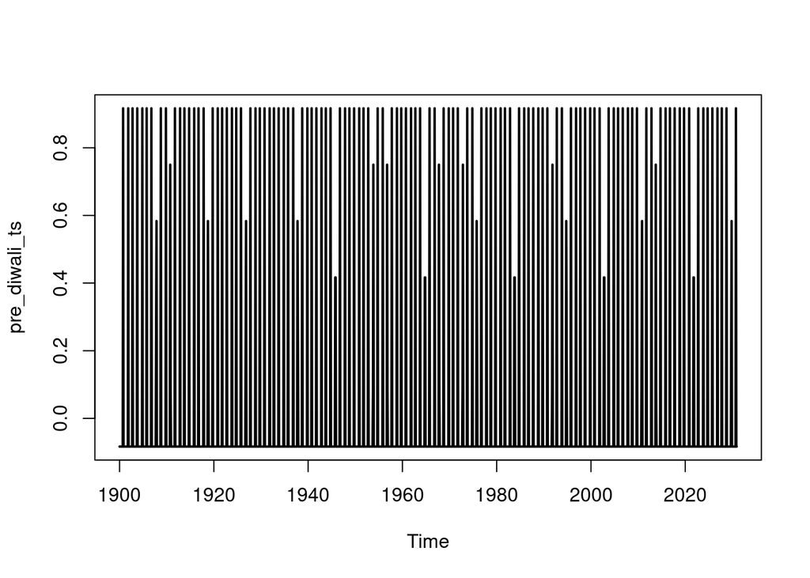

```r
ts.plot(pre_diwali_ts,lwd = c(2, 1))
```

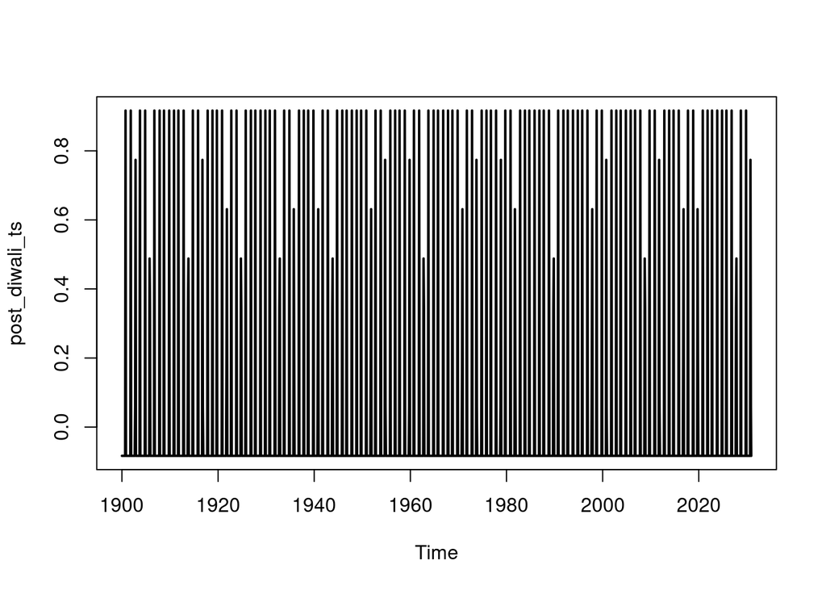

```r
ts.plot(post_diwali_ts,lwd = c(2, 1))
```

### Including user defined regressors

The `seasonal` package allows to add user-defined regressors to remove seasonality from a time-series. Here `pre_diwali_ts` and `post_diwali_ts` are added in the main seasonal adjustment. `X-13ARIMA-SEATS` is used to adjust for the festival seasonal component.

```r
m1 <- seas(industrial_prod, xreg = cbind(pre_diwali_ts, post_diwali_ts), regression.usertype = "holiday", x11 = list())
```

`xreg` adds the user-defined regressors and `x11` is chosen as the decomposition effect.

```r
summary(m1)
```

```
##
## Call:
## seas(x = industrial_prod, xreg = cbind(pre_diwali_ts, post_diwali_ts),
##     regression.usertype = "holiday", x11 = list())
##
## Coefficients:
##                     Estimate Std. Error z value Pr(>|z|)
## xreg1             -0.0034498  0.0091813  -0.376  0.70711
## xreg2             -0.0383834  0.0081358  -4.718 2.38e-06 ***
## Weekday            0.0012087  0.0004275   2.827  0.00469 **
## Constant          -0.0014297  0.0003227  -4.431 9.39e-06 ***
## LS2008.Nov        -0.0738919  0.0160213  -4.612 3.99e-06 ***
## MA-Nonseasonal-01  0.4328295  0.0785625   5.509 3.60e-08 ***
## MA-Seasonal-12     0.9995753  0.0785461  12.726  < 2e-16 ***
## ---
## Signif. codes:  0 '***' 0.001 '**' 0.01 '*' 0.05 '.' 0.1 ' ' 1
##
## X11 adj.  ARIMA: (0 1 1)(0 1 1)  Obs.: 116  Transform: log
## AICc: 543.2, BIC: 562.7  QS (no seasonality in final):    0
## Box-Ljung (no autocorr.): 31.53   Shapiro (normality): 0.9894
```

The seasonal co-efficient shows minor decline during pre and post Diwali season across the time-series. In the below unadjusted v adjusted seasonal plot it can be observed that seasonal adjustment based on Diwali season removes distortion from the time-series.

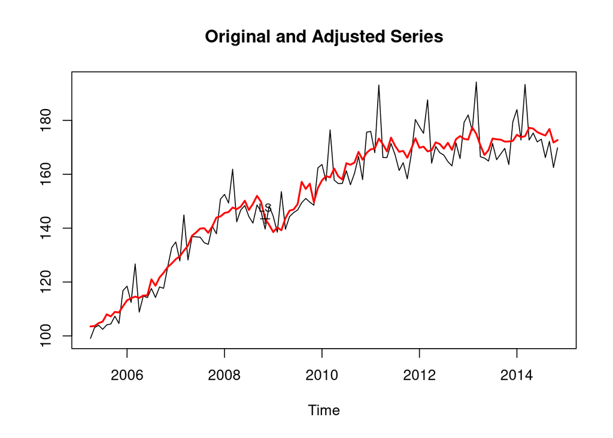

```r
plot(m1)
```

### Comparing the series

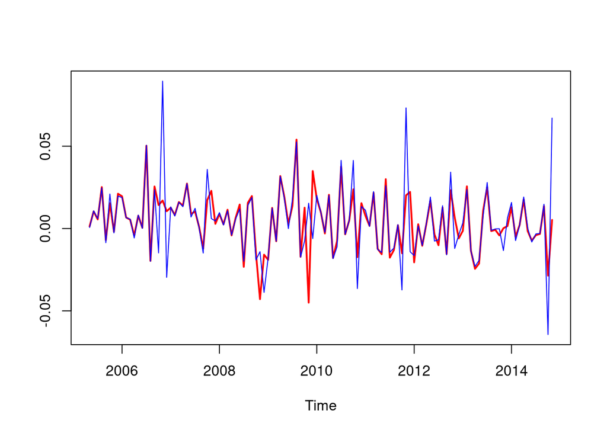

```r
m2 <- seas(x = iip, x11 = list(), regression.variables = c("td1coef", "ls2008.Nov"),
           arima.model = "(0 1 1)(0 1 1)", regression.aictest = NULL, outlier = NULL,
           transform.function = "log")
ts.plot(diff(log(cbind(final(m1), final(m2)))), col = c("red", "blue"),
        lwd = c(2, 1))
```

In the above chart, non-adjusted(blue) vs adjusted(red) seasonal plot clearly shows the amount of distortion present in the series.

The below chart also indicated a level of distortion present for industrial output due to Diwali festival.

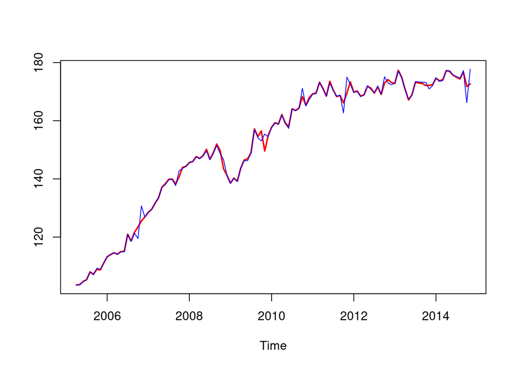

```r
ts.plot(final(m1), final(m2), col = c("red", "blue"), lwd = c(2, 1))
```

Sax, Christoph, and Dirk Eddelbuettel. 2018. “Seasonal Adjustment by x-13arima-SEATS in r” 87. https://doi.org/10.18637/jss.v087.i11.